# 0326

## Setting up

```r
#####
# set up the environment
#####
# load packages
library(brms)
#library(rethinking)
options(mc.cores = parallel::detectCores())
#rstan_options(auto_write = TRUE)

# adjust the plot region for viewing on the projector in class
options(repr.plot.height=5)
```

```
Loading 'brms' package (version 2.8.0). Useful instructions
can be found by typing help('brms'). A more detailed introduction
to the package is available through vignette('brms_overview').
```

```r
d <- read.csv("https://mcmahanp.github.io/soci620/data/t_star_student_grade1_2l.csv")
```

```r
# select 20 schools
t_ids <- unique(d$teacher_id)
t_ids <- sample(t_ids,20)
```

```r
# subset the data
d <- d[d$teacher_id %in% t_ids,]
# keep only students who are white or Black
d <- d[d$student_re_white | d$student_re_black,]
```

```r
# create a standardized age variable
st <- function(x){
    (x-mean(x,na.rm=TRUE))/sd(x,na.rm=TRUE)
}

d$student_age_s <- st(-d$student_born)
```

## Random-intercept model

Picking up where we left off, we will ask `brm()` to estimate a random-intercept model. For illustrative purposes, let's set different priors for the intercept ($\gamma_{00}$), the coefficient on age ($\beta_1$}, and use the same prior for coefficients on the two indicator variables ($\beta_2$ and $\beta_3$). We will use half-Cauchy distributions for the standard-deviation paramters.

$$ S_{ik} \sim \mathrm{Norm}(\mu_{ik},\sigma)\\ \mu_{ik} = \beta_{0k} + \beta_{1}Age_i + \beta_{2}Female_i + \beta_{3}Black_i\\ \beta_{0k} = \gamma_{00} + \eta_{0k}\\ \eta_{0k} \sim \mathrm{Norm}(0,\phi_0) $$

$$ \gamma_{00}\sim\mathrm{Norm}(500,100)\\ \beta_1\sim\mathrm{Norm}(0,50)\\ \beta_1,\beta_2\sim\mathrm{Norm}(0,100)\\ \sigma\sim \mathrm{halfCauchy}(0,50)\\ \phi_0\sim \mathrm{halfCauchy}(0,50) $$

```r
# you can break the formula up onto multiple lines, as long as
# each line ends with an operation like `~` or `+`
m_1 <- student_reading_score ~
    1 + student_age_s + student_re_black + student_female +
    (1 | teacher_id)

fit_1 <- brm(
    formula=m_1,
    data=d,
    prior=c(
        set_prior("normal(500,100)",class="Intercept"), # gamma_00
        set_prior("normal(0,100)",class='b'), # default prior for coefficients
        set_prior("normal(0,50)",class='b',coef='student_age_s'), # exception for `student_age_s`
        set_prior("cauchy(0,50)",class='sigma'), # sigma
        set_prior("cauchy(0,50)",class='sd') # phi_0
    )
)
```

Setting priors in `brm()` is quite awkward, especially because it does not know about the hierarchical structure we used to construct our model. The function breaks up priors into multiple 'classes' of parameter. The (fixed) intercept always has its own prior, with class "Intercept".

Every coefficient (Any $\beta$ parameter that does not have a random component, and all of the $\gamma$ parameters) has class 'b'. You can set one prior for all of these coefficients, and then set exceptions to that prior for coefficients that you want different priors for. In the code above, we made the default prior on coefficients $\mathrm{Norm}(0,100)$, but explicitly set a narrower prior for `student_age_s`.

The population-level standard deviation ($\sigma$) has class 'sigma', while the standard deviation the random effects all are of class 'sd'. In this case we only have one second-level random effect ($\phi_0$).

This system for setting priors is very flexible, but not especially intuitive. You can read the sometimes-helpful description of priors in `brms` with `?set_prior`.

We'll make sure our priors were set correctly by asking to look at them with the `prior_summary()` function:

```r
prior_summary(fit_1)
```

| prior | class | coef | group | resp | dpar | nlpar | bound |
| --- | --- | --- | --- | --- | --- | --- | --- |
| normal(0,100) | b |  |  |  |  |  |  |
| normal(0,50) | b | student_age_s |  |  |  |  |  |
|  | b | student_femaleTRUE |  |  |  |  |  |
|  | b | student_re_blackTRUE |  |  |  |  |  |
| normal(500,100) | Intercept |  |  |  |  |  |  |
| cauchy(0,50) | sd |  |  |  |  |  |  |
|  | sd |  | teacher_id |  |  |  |  |
|  | sd | Intercept | teacher_id |  |  |  |  |
| cauchy(0,50) | sigma |  |  |  |  |  |  |

(Notice that the 'coef' for the binary variables has '`TRUE`' appended to it. This is because R is taking a logical value (TRUE/FALSE) and converting it to an indicator (1/0) automatically. Whenever it does this, it appends the value assigned to '1' to the end of the variable name. In this case, it is telling us that it set `TRUE` to 1.)

Once we sort out how that table is formatted, the priors look right. Let's take a look at a summary of the estimates.

```r
summary(fit_1,prob=.89)
```

```
 Family: gaussian
  Links: mu = identity; sigma = identity
Formula: student_reading_score ~ 1 + student_age_s + student_re_black + student_female + (1 | teacher_id)
   Data: d (Number of observations: 383)
Samples: 4 chains, each with iter = 2000; warmup = 1000; thin = 1;
         total post-warmup samples = 4000

Group-Level Effects:
~teacher_id (Number of levels: 19)
              Estimate Est.Error l-89% CI u-89% CI Eff.Sample Rhat
sd(Intercept)    24.47      5.42    16.92    33.80       1242 1.00

Population-Level Effects:
                     Estimate Est.Error l-89% CI u-89% CI Eff.Sample Rhat
Intercept              532.59      7.01   521.33   543.38       1667 1.00
student_age_s           -8.19      2.64   -12.40    -3.92       4256 1.00
student_re_blackTRUE   -26.41      8.98   -40.56   -12.00       3260 1.00
student_femaleTRUE      10.59      4.96     2.71    18.57       5400 1.00

Family Specific Parameters:
      Estimate Est.Error l-89% CI u-89% CI Eff.Sample Rhat
sigma    48.88      1.83    46.10    51.90       4505 1.00

Samples were drawn using sampling(NUTS). For each parameter, Eff.Sample
is a crude measure of effective sample size, and Rhat is the potential
scale reduction factor on split chains (at convergence, Rhat = 1).
```

The summary has some information on "group-level" (as opposed to "population-level") effects. Because we only have a random intercept the information on this is limited to a standard deviation. In the model above, this corresponds to the standard deviation of the random effects, $\phi_0=SD(\eta_{0k})$. The estimate puts it at around 25, which tells us the scale of variation between classes in average test score. 100 points (about four standard deviations) will cover about 95% of the variation in average scores between the classes.

```r
(re_1 <- ranef(fit_1))
dim(re_1$teacher_id)
```

1. 19

2. 4

3. 1

`ranef()` returns a list with one element for each grouping variable. In this case, we have just one: `teacher_id`. Jupyter notebook is horrible at printing these lists out, so we should look just at the first (and only) element of the list, which has 3 'dimensions'. The following is a cludge that will show you the estimates for the random effect on the intercept.

```r
re_1$teacher_id[,,"Intercept"]
```

|  | Estimate | Est.Error | Q2.5 | Q97.5 |
| --- | --- | --- | --- | --- |
| 12305604 | -38.5626391 | 11.44333 | -62.085764 | -16.685125 |
| 13008506 | 31.3168971 | 11.19160 | 9.759814 | 53.459867 |
| 16117606 | -17.2131466 | 10.92890 | -38.455262 | 4.631619 |
| 16118312 | 33.3469919 | 12.95693 | 8.618551 | 58.701196 |
| 16218407 | -4.6693044 | 11.74691 | -27.701640 | 18.048182 |
| 16821405 | 32.4353626 | 11.42437 | 10.389464 | 55.015054 |
| 16922909 | 0.8171132 | 11.86749 | -22.508666 | 24.557186 |
| 16922915 | -6.7998494 | 11.70459 | -29.567668 | 16.288890 |
| 16928007 | -12.6237724 | 10.64973 | -33.875482 | 8.035694 |
| 17029507 | 14.9775281 | 11.26045 | -6.855957 | 37.445158 |
| 18034407 | -10.8011032 | 11.18804 | -33.029668 | 10.663054 |
| 20144910 | 27.0124222 | 11.00842 | 6.318036 | 49.812422 |
| 20345705 | 6.8658029 | 11.13199 | -14.248211 | 29.438965 |
| 20549107 | 1.7076542 | 11.65012 | -20.562236 | 24.168683 |
| 24472806 | -22.7894478 | 12.83794 | -48.392543 | 2.112350 |
| 24474506 | -21.9054021 | 12.17998 | -46.474317 | 1.059185 |
| 24475513 | -19.9882608 | 12.76714 | -45.673983 | 4.231099 |
| 25789909 | 0.7659477 | 12.49046 | -23.709749 | 25.279064 |
| 26192705 | 11.6598934 | 11.71575 | -10.610021 | 35.696126 |

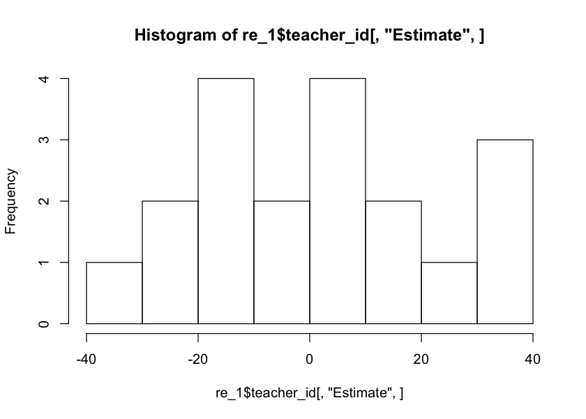

```r
hist(re_1$teacher_id[,"Estimate",])
```

Each class has its own estimate, along with a 95% credible interval and a standard error on that estimate.

## Random slopes

Adding random slopes to the model is straightforward when there are no second-level predictors for the slopes (e.g. the effect of teacher sex on $\beta{2k}$). The model is specified in a hierarchical framework by adding formulas for each of the level-one $\beta$ parameters. We also model the joint distribution of $(\eta_{0k},\eta_{1k},\eta_{2k},\eta_{3k}) = \eta_{\cdot k}$ using a multivariate normal distribution with an LKJ(2,4) prior on the correlation matrix.

$$\begin{align} S_{ik} &\sim \mathrm{Norm}(\mu_{ik},\sigma)\\ \mu_{ik} &= \beta_{0k} + \beta_{1k}Age_i + \beta_{2k}Female_i + \beta_{3k}Black_i\\ \beta_{0k} &= \gamma_{00} + \eta_{0k}\\ \beta_{1k} &= \gamma_{10} + \eta_{1k}\\ \beta_{2k} &= \gamma_{20} + \eta_{2k}\\ \beta_{3k} &= \gamma_{30} + \eta_{3k}\\ \eta_{\cdot k} &\sim \mathrm{MVNorm}(0,\Phi,R)\\ \\ \gamma_{00}&\sim\mathrm{Norm}(500,100)\\ \gamma_{10}&\sim\mathrm{Norm}(0,50)\\ \gamma_{20},\gamma_{30}&\sim\mathrm{Norm}(0,100)\\ \sigma&\sim \mathrm{halfCauchy}(0,50)\\ \phi_k&\sim \mathrm{halfCauchy}(0,50)\\ R &\sim LKJ(2,4) \end{align} $$

```r
m_2 <- student_reading_score ~
    student_age_s + student_re_black + student_female +
    (1 + student_age_s + student_re_black + student_female | teacher_id)

fit_2 <- brm(
    formula=m_2,
    data=d,
    prior=c(
        set_prior("normal(500,100)",class="Intercept"), # gamma_00
        set_prior("normal(0,100)",class='b'), # default prior for coefficients
        set_prior("normal(0,50)",class='b',coef='student_age_s'), # exception for `student_age_s`
        set_prior("cauchy(0,50)",class='sigma'), # sigma
        set_prior("cauchy(0,50)",class='sd'), # phi_0, phi_1, phi_2, phi_3,
        set_prior('lkj(2)',class='cor') # R (this can have class='L')
    ),
    chains=8,iter=1500,warmup=1000,cores=8,
    control=list(adapt_delta=.99)
)
```

We added one new line to `prior`, which specifies the LKJ prior on the correlation matrix. LKJ is actually the default prior for correlations in `brm()`, but it uses a concentration parameter of 1 unless you tell it otherwise.

We also snuck in a few more arguments to `brm()`. The last one, `control`, is just a way to pass "control" instructions to the underlying Stan program. In this case, telling Stan to set `adapt_delta=.99` has it take smaller steps as it is tuning its HMC chain. You don't need to know the details of this, but it is a pretty common adjustment when using Stan.

We also added values for `chains`, `iter`, `warmup`, and `cores`. These are not strictly necessary, but learning to use them can make your models run much faster on a multi-core computer (like most are these days). The following figure can help explain how this speedup can work. In general, once the Stan program is compiled, it can run each HMC chain in its own 'process' or 'thread' (we can ignore the distinction between 'process' and 'thread' here). Ideally, these processes execute in parallel on your computer, multitasking the job of drawing posterior samples. The figure below illustrates the possible gains from increasing the number of processes that you allow `brm()` to launch, and the number of HMC chains you tell it to use.

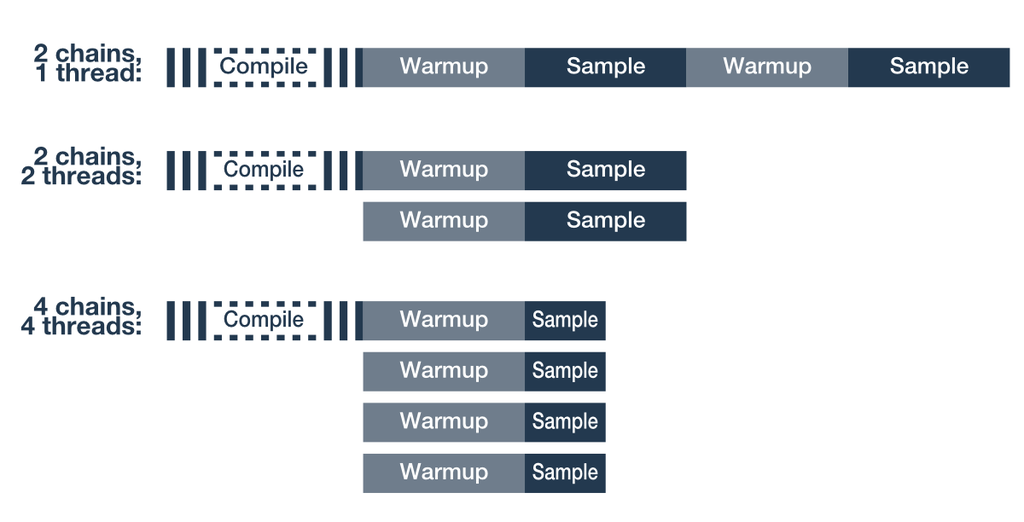

In the first example, there are two chains being run on one thread. By splitting this up into two threads (`cores=2`, e.g.) in the second example, the sampling portion of the model takes about half as long. In the third example, we get the same number of post-warmup samples by runnign four chains on four threads, but cutting the number of post-warmup iterations in half. (Note that in practice, you almost always want at least 4 chains, which helps with effective sample size and accurate values of $\hat{R}$.)

In the function call above, we split the 4000 post-warmup sample across 8 chains in 8 threads, each of which had 1000 warmup iterations and 1500-1000=500 post-warmup iterations.

You can tell how many cores your computer has with the `parallel::detectCores()` function.

```r
parallel::detectCores()
```

12

The summary of `fit_2` now includes a standard deviation for each second-level random effect, and a the correlation between each pair of them. This means it takes a lot more space to print out.

```r
summary(fit_2)
```

```
 Family: gaussian
  Links: mu = identity; sigma = identity
Formula: student_reading_score ~ student_age_s + student_re_black + student_female + (1 + student_age_s + student_re_black + student_female | teacher_id)
   Data: d (Number of observations: 383)
Samples: 8 chains, each with iter = 1500; warmup = 1000; thin = 1;
         total post-warmup samples = 4000

Group-Level Effects:
~teacher_id (Number of levels: 19)
                                             Estimate Est.Error l-95% CI
sd(Intercept)                                   24.16      5.66    14.86
sd(student_age_s)                                2.79      2.26     0.09
sd(student_re_blackTRUE)                        14.86     11.12     0.70
sd(student_femaleTRUE)                           6.72      5.24     0.23
cor(Intercept,student_age_s)                     0.01      0.37    -0.68
cor(Intercept,student_re_blackTRUE)              0.05      0.35    -0.62
cor(student_age_s,student_re_blackTRUE)          0.02      0.38    -0.70
cor(Intercept,student_femaleTRUE)               -0.02      0.37    -0.71
cor(student_age_s,student_femaleTRUE)            0.04      0.38    -0.68
cor(student_re_blackTRUE,student_femaleTRUE)     0.04      0.37    -0.69
                                             u-95% CI Eff.Sample Rhat
sd(Intercept)                                   37.34       1371 1.01
sd(student_age_s)                                8.35       3723 1.00
sd(student_re_blackTRUE)                        42.38       1562 1.00
sd(student_femaleTRUE)                          19.44       1724 1.00
cor(Intercept,student_age_s)                     0.71       6076 1.00
cor(Intercept,student_re_blackTRUE)              0.70       4926 1.00
cor(student_age_s,student_re_blackTRUE)          0.72       3034 1.00
cor(Intercept,student_femaleTRUE)                0.68       5127 1.00
cor(student_age_s,student_femaleTRUE)            0.71       3308 1.00
cor(student_re_blackTRUE,student_femaleTRUE)     0.73       3409 1.00

Population-Level Effects:
                     Estimate Est.Error l-95% CI u-95% CI Eff.Sample Rhat
Intercept              533.48      6.97   519.93   547.36       1356 1.00
student_age_s           -8.17      2.83   -13.95    -2.59       5245 1.00
student_re_blackTRUE   -26.20     10.51   -46.13    -5.17       3079 1.00
student_femaleTRUE      10.31      5.50    -0.22    21.08       4948 1.00

Family Specific Parameters:
      Estimate Est.Error l-95% CI u-95% CI Eff.Sample Rhat
sigma    48.81      1.90    45.27    52.58       5038 1.00

Samples were drawn using sampling(NUTS). For each parameter, Eff.Sample
is a crude measure of effective sample size, and Rhat is the potential
scale reduction factor on split chains (at convergence, Rhat = 1).
```

```r
m_2_nocor <- student_reading_score ~
    student_age_s + student_re_black + student_female +
    (1 + student_age_s + student_re_black + student_female || teacher_id)

fit_2_nocor <- brm(
    formula=m_2,
    data=d,
    prior=c(
        set_prior("normal(500,100)",class="Intercept"), # gamma_00
        set_prior("normal(0,100)",class='b'), # default prior for coefficients
        set_prior("normal(0,50)",class='b',coef='student_age_s'), # exception for `student_age_s`
        set_prior("cauchy(0,50)",class='sigma'), # sigma
        set_prior("cauchy(0,50)",class='sd') # phi_0, phi_1, phi_2, phi_3,
    ),
    chains=8,iter=1500,warmup=1000,cores=8,
    control=list(adapt_delta=.99)
)
```

Comparing the information criteria and fixed-effects estimates, we see that they are almost identical in terms of fit.

```r
waic(fit_2,fit_2_nocor)
```

```
Output of model 'fit_2':

Computed from 4000 by 383 log-likelihood matrix

          Estimate   SE
elpd_waic  -2044.5 13.0
p_waic        23.0  1.6
waic        4089.0 26.1

Output of model 'fit_2_nocor':

Computed from 4000 by 383 log-likelihood matrix

          Estimate   SE
elpd_waic  -2044.5 13.0
p_waic        22.9  1.6
waic        4089.0 26.0

Model comparisons:
            elpd_diff se_diff
fit_2       0.0       0.0
fit_2_nocor 0.0       0.1
```

```r
fixef(fit_2)
fixef(fit_2_nocor)
fixef(fit_1)
```

|  | Estimate | Est.Error | Q2.5 | Q97.5 |
| --- | --- | --- | --- | --- |
| Intercept | 533.482992 | 6.973929 | 519.9284268 | 547.359510 |
| student_age_s | -8.172586 | 2.830629 | -13.9480164 | -2.592884 |
| student_re_blackTRUE | -26.196491 | 10.510875 | -46.1280272 | -5.167766 |
| student_femaleTRUE | 10.312279 | 5.496068 | -0.2158166 | 21.076379 |

|  | Estimate | Est.Error | Q2.5 | Q97.5 |
| --- | --- | --- | --- | --- |
| Intercept | 533.375036 | 7.219270 | 518.6441407 | 547.378858 |
| student_age_s | -8.273041 | 2.874789 | -13.8437970 | -2.708610 |
| student_re_blackTRUE | -26.480723 | 10.313378 | -46.6499776 | -5.749221 |
| student_femaleTRUE | 10.368927 | 5.593662 | -0.4089267 | 21.754916 |

|  | Estimate | Est.Error | Q2.5 | Q97.5 |
| --- | --- | --- | --- | --- |
| Intercept | 532.590016 | 7.005658 | 518.4877897 | 545.936641 |
| student_age_s | -8.188375 | 2.635821 | -13.2529811 | -3.206184 |
| student_re_blackTRUE | -26.410656 | 8.982730 | -43.6883668 | -8.879013 |
| student_femaleTRUE | 10.591353 | 4.960543 | 0.8510038 | 20.134338 |

## Group-level predictors

For the sake of completenesss, let's estimate the full model from lecture, including group-level predictors (leaving off the priors for brevity).

$$\begin{align} S_{ik} &\sim \mathrm{Norm}(\mu_{ik},\sigma)\\ \mu_{ik} &= \beta_{0k} + \beta_{1k}Age_i + \beta_{2k}Female_i + \beta_{3k}Black_i\\ \\ \beta_{0k} &= \gamma_{00} + \gamma_{01}Size_k + \gamma_{02}Exp_i + \gamma_{03}TeacherFemale_k+\\ &\phantom{{}={}}\gamma_{04}TeacherBlack_k+\gamma_{05}PropBlack_k+\eta_{0k}\\ \beta_{1k} &= \gamma_{10} + \gamma_{11}Size_k + \eta_{1k}\\ \beta_{2k} &= \gamma_{20} + \gamma_{21}TeacherFemale_k + \eta_{2k}\\ \beta_{3k} &= \gamma_{30} + \gamma_{31}TeacherBlack_k + \gamma_{32}PropBlack_k+\eta_{3k} \end{align} $$

```r
# get class sizes and teacher experience without repeats
class_data <- na.omit(unique(d[c('teacher_id','class_size','teacher_exper')]))
# center class size and teacher experience
d$class_size_c <- d$class_size-mean(class_data$class_size)
d$teacher_exp_c <- d$teacher_exper-mean(class_data$teacher_exp)
```

```r
m_3 <- student_reading_score ~
    student_age_s*class_size_c + teacher_exp_c +
    student_female*teacher_female +
    student_re_black*teacher_re_black + student_re_black*class_prop_black +
    (1 +
        student_age_s +
        student_female +
        student_re_black
        |teacher_id)

t0 <- Sys.time() # time the execution
fit_3 <- brm(
    formula=m_3,
    data=d,
    prior=c(
        set_prior("normal(500,100)",class="Intercept"), # gamma_00
        set_prior("normal(0,100)",class='b'), # default prior for coefficients
        set_prior("normal(0,50)",class='b',coef='student_age_s'), # exception for `student_age_s`
        set_prior("cauchy(0,50)",class='sigma'), # sigma
        set_prior("cauchy(0,50)",class='sd'), # phi_0, phi_1, phi_2, phi_3,
        set_prior('lkj(2)',class='cor') # R (this can have class='L')
    ),
    chains=8,iter=1500,warmup=1000,cores=8,
    control=list(adapt_delta=.99)
)
t1 <- Sys.time()
t1-t0
```

```
Time difference of 1.481796 mins
```

```r
summary(fit_3)
```

```
 Family: gaussian
  Links: mu = identity; sigma = identity
Formula: student_reading_score ~ student_age_s * class_size_c + teacher_exp_c + student_female * teacher_female + student_re_black * teacher_re_black + student_re_black * class_prop_black + (1 + student_age_s + student_female + student_re_black | teacher_id)
   Data: d (Number of observations: 383)
Samples: 8 chains, each with iter = 1500; warmup = 1000; thin = 1;
         total post-warmup samples = 4000

Group-Level Effects:
~teacher_id (Number of levels: 19)
                                             Estimate Est.Error l-95% CI
sd(Intercept)                                   24.92      6.18    14.90
sd(student_age_s)                                3.00      2.35     0.15
sd(student_femaleTRUE)                           6.70      5.11     0.26
sd(student_re_blackTRUE)                        12.50     10.41     0.36
cor(Intercept,student_age_s)                    -0.02      0.38    -0.72
cor(Intercept,student_femaleTRUE)               -0.05      0.36    -0.69
cor(student_age_s,student_femaleTRUE)            0.05      0.38    -0.68
cor(Intercept,student_re_blackTRUE)             -0.06      0.38    -0.74
cor(student_age_s,student_re_blackTRUE)          0.01      0.38    -0.71
cor(student_femaleTRUE,student_re_blackTRUE)     0.04      0.39    -0.70
                                             u-95% CI Eff.Sample Rhat
sd(Intercept)                                   39.03       1741 1.00
sd(student_age_s)                                8.86       3167 1.00
sd(student_femaleTRUE)                          19.17       2273 1.00
sd(student_re_blackTRUE)                        37.17       2069 1.01
cor(Intercept,student_age_s)                     0.69       5539 1.00
cor(Intercept,student_femaleTRUE)                0.66       5817 1.00
cor(student_age_s,student_femaleTRUE)            0.73       3575 1.00
cor(Intercept,student_re_blackTRUE)              0.68       5194 1.00
cor(student_age_s,student_re_blackTRUE)          0.71       3358 1.00
cor(student_femaleTRUE,student_re_blackTRUE)     0.75       3201 1.00

Population-Level Effects:
                                          Estimate Est.Error l-95% CI u-95% CI
Intercept                                   537.53     98.49   346.21   732.94
student_age_s                                -8.06      2.94   -13.76    -2.15
class_size_c                                 -1.18      1.83    -4.70     2.43
teacher_exp_c                                 0.20      1.13    -2.00     2.43
student_femaleTRUE                            5.48     73.45  -139.65   151.63
teacher_femaleTRUE                           -0.04     98.07  -192.73   193.61
```

[output cut: 14 more lines]

```
student_re_blackTRUE                            2684 1.00
teacher_re_blackTRUE                            6046 1.00
class_prop_black                                2048 1.00
student_age_s:class_size_c                      6702 1.00
student_femaleTRUE:teacher_femaleTRUE           3118 1.00
student_re_blackTRUE:teacher_re_blackTRUE       5985 1.00
student_re_blackTRUE:class_prop_black           2051 1.00

Family Specific Parameters:
      Estimate Est.Error l-95% CI u-95% CI Eff.Sample Rhat
sigma    48.87      1.86    45.48    52.73       5082 1.00

Samples were drawn using sampling(NUTS). For each parameter, Eff.Sample
is a crude measure of effective sample size, and Rhat is the potential
scale reduction factor on split chains (at convergence, Rhat = 1).
```

```r
fixef(fit_3)
```

|  | Estimate | Est.Error | Q2.5 | Q97.5 |
| --- | --- | --- | --- | --- |
| Intercept | 537.52525684 | 98.4852449 | 346.205342 | 732.941519 |
| student_age_s | -8.06156279 | 2.9399065 | -13.759624 | -2.154419 |
| class_size_c | -1.17798258 | 1.8279162 | -4.696050 | 2.429233 |
| teacher_exp_c | 0.19685626 | 1.1318024 | -2.002991 | 2.425566 |
| student_femaleTRUE | 5.48384218 | 73.4498294 | -139.650723 | 151.634963 |
| teacher_femaleTRUE | -0.04434407 | 98.0718980 | -192.727369 | 193.607459 |
| student_re_blackTRUE | -9.62893800 | 16.9203574 | -43.998734 | 23.047728 |
| teacher_re_blackTRUE | 1.36139324 | 102.1520358 | -190.992810 | 200.082941 |
| class_prop_black | -20.82632492 | 34.1257900 | -87.619427 | 45.575143 |
| student_age_s:class_size_c | -0.23990529 | 0.9532152 | -2.058264 | 1.673683 |
| student_femaleTRUE:teacher_femaleTRUE | 4.86870784 | 73.3706960 | -142.346084 | 150.700376 |
| student_re_blackTRUE:teacher_re_blackTRUE | 0.87344692 | 98.4753287 | -196.576437 | 190.865758 |
| student_re_blackTRUE:class_prop_black | -28.99746169 | 42.4614326 | -112.817444 | 53.979442 |